# Dispersal.jl example on resistance

**Author:** Virgile Baudrot  
**Date:** 2020-10-29

# 1 Population model

We start with the simplest population model, with $t$ a generation (not a day). Therefore, from generation $t-1$, and its density $N_{t-1}$ the density at generation $N_t$ is given by the exponential model:
$$N_t = w_t N_{t-1},$$
where:

- $N_t$ is the population density at generation $t$,
- $w_t$ is the population growth rate.

The population growth rate is made of (1) the fecundity rate, denoted $f_t$, and (2) the survival rate during generation $t$ for each individuals stages, denoted $S_{stage}$.

To define the fecundity $f$, we would need for instance:

1. the per capita fecundity, which is the number of egg a female can produce (50 to 200 eggs layed in cluster)
2. the sex ratio (usually 0.5)
3. the overwintering mortality rate

For the survival rate, ignoring ecological process:

1. we may use the dose-response experiment,
2. the ration $1/timespan$

$$N_t = f \times S_{eggs} \times S_{larvae} \times S_{pupae} \times S_{adults} \times N_{t-1}$$

Let assume that pesticide target only larval stage, so $S_{larvae}$ is the survival rate that is targetted by pesticide.

The simplest model of $S_{larvae}$ is given by a dose-response model (which is relevant considering a whole generation). If we call $C_{ext}$ the exposure concentration, then:

$$S_{larvae} = S^0_{larvae} \times \frac{1}{1+(C_{ext} / LC_{50})^H}$$

And therefore the general model is simply:

$$N_t = f \times S_{eggs} \times S^0_{larvae} \times \frac{1}{1+(C_{ext} / LC_{50})^H} \times S_{pupae} \times S_{adults} \times N_{t-1}$$

- $f$ fecondity rate,
- $S_{stage}$ survival rate for each phenology stages
- $S_{larvae}$ include dose-response to pesticide with the control survival rate $S^0_{larvae}$ and the dose-response survival rate

The following graph show dynamic of population (over 50 generations) with a discrete growth rate of $f=2.2$ between generation and the same “sensitivity” to the “contaminant” $LC_{50} = 10.0$. The exposure profile is given by:

```julia
julia> using Dispersal

julia> gridSize = 100;

julia> populationSize = convert(Array{Float64,2},[i for i in 1:gridSize] * fill(1,gridSize)');

julia> exposure = convert(Array{Float64,2},fill(1,gridSize) * [i for i in 1:gridSize]');

julia> output = ArrayOutput(populationSize; tspan=1:50,aux=(exposure=exposure,));

julia> growthRule = DiscreteGrowth(intrinsicrate=2.2);

julia> survivalRule = SurvLogLogisticMap(layerkey=Val(:exposure), LC50=10.0, hillcoefficient=0.1);

julia> ruleset = Ruleset(Chain(growthRule, survivalRule));

julia> sim!(output, ruleset);
```

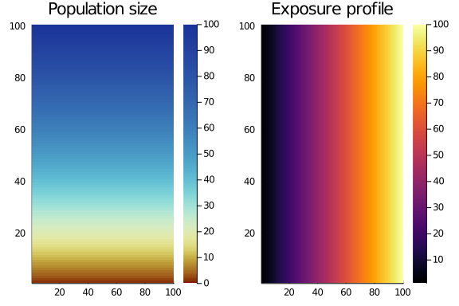

```julia
julia> using Plots

julia> plot(
           heatmap(populationSize,
                   title = "Population size",
                   c = cgrad(:roma, scale = :exp),
                   clims=(0.0, 100.0)),
           heatmap(exposure, title = "Exposure profile"),
           layout = (1,2)
           )
```

The resulting populations sequence is given in these graphics:

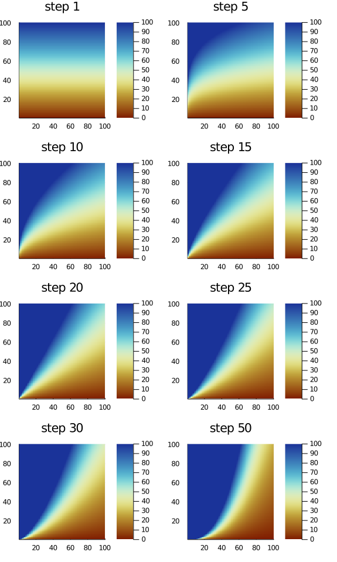

```julia
julia> plt = [ heatmap(
                   output[i],
                   title = "step $i",
                   c = cgrad(:roma),
                   clims=(0.0, 100.0)) for i in 1:length(output)];

julia> plot(plt[1],plt[5],plt[10],plt[15],plt[20],plt[25],plt[30],plt[50], layout = (4,2))
```

The Hill coefficient has a real importance since we can smoother response to selection:

```julia
julia> gridSize = 100;

julia> populationSize = convert(Array{Float64,2},[i for i in 1:gridSize] * fill(1,gridSize)');

julia> exposure = convert(Array{Float64,2},fill(1,gridSize) * [i for i in 1:gridSize]');

julia> output = ArrayOutput(populationSize; tspan=1:50,aux=(exposure=exposure,));

julia> growthRule = DiscreteGrowth(intrinsicrate=2.2);

julia> survivalRule = SurvLogLogisticMap(layerkey=Val(:exposure), LC50=50.0, hillcoefficient=2.0);

julia> ruleset = Ruleset(Chain(growthRule, survivalRule));

julia> sim!(output, ruleset);
```

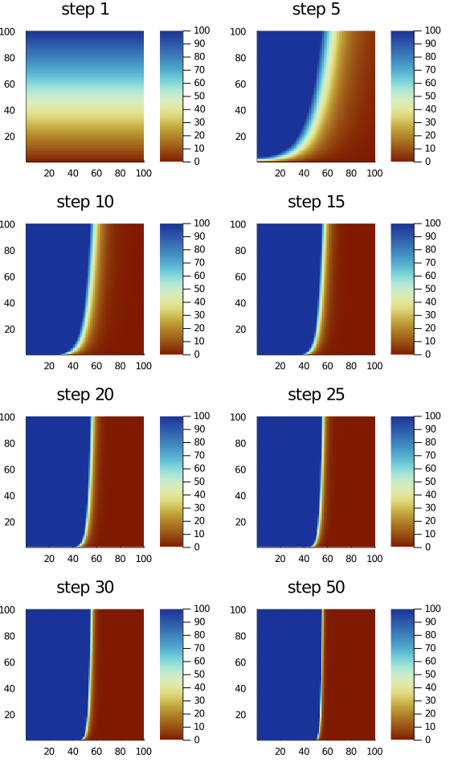

```julia
julia> plt = [ heatmap(
                   output[i],
                   title = "step $i",
                   c = cgrad(:roma),
                   clims=(0.0, 100.0)) for i in 1:length(output)];

julia> plot(plt[1],plt[5],plt[10],plt[15],plt[20],plt[25],plt[30],plt[50], layout = (4,2))
```

# 2 Quantitative genetics model

We start with the breeder’s equation:
$$R = h^2 S$$

- $R$ is the selection response of trait = *the change in mean within a population across a generation*,
- $h^2$ is the heritability of the trait = *a measure of how the character value is passed across generations* ,
- $S$ is the selection differential = *the product of wihin-generation change*

There is some assumption in the breeder’s equations: * a necessary (but not sufficient) condition is a linear parent-offspring regression, with the phenotype value $z_o$ of an offspring whose parents have mean phenotypic value, $z_{mp}$:
$$z_o = b_{o \vert mp} (z_{mp} - \mu) + e$$
* it is assumed that the residuals of the linear parent-offspring and fitness-phenotype regressions are uncorrelated with each-other. * it is assumed that the mean does not change in the absence of selection.

The heritability is given by

$$h^2 = V_A /V_P$$

with $V_A$ the additive genetic variance and $V_P$ the phenotypic variance such as $V_P = V_A + V_E$ with $V_E$ the environmental variance.

In all what follow, we assume the population trait we follow, the $LC_{50}$ is normally distributed.

## 2.1 Selection differential

The Robertson-Price identity is given by $S = \sigma(w, z)$ which is the covariance between:

- relative fitness $w$, and
- the trait value $z$.

The selection differential is simply the mean after selection, $\mu_s$, minus the mean before $\mu$. If we name $z_i$, $p_i$ and $w_i$ the trait value, the frequency before selection, and the relative fitness respecivelly than:
$$S = \mu_s - \mu = \sum z_i w_i p_i - \sum z_i p_i = E[zw ] - E[z]$$

Note that $w_i p_i$ is the frequency of $z_i$ after selection because of the fitness weigth $w_i$. Since $E[w] = 1$ by definition, we can write:

$$S = E[zw] - E[z] E[w] = \sigma(w,z)$$

If we consider the least squares linear regression of relative fitness $w$ on a phenotypic trait $z$:

$$w = \alpha + \beta z + \varepsilon$$
then the slope $\beta$ means that a change in $z$ results in a change in relative fitness $\beta$:

$$\beta = \frac{\sigma(z,w)}{\sigma^2_z} = \frac{S}{\sigma^2_z}$$

So $S = \beta \sigma^2_z$, and so from the breeder’s equation:

$$R = h^2 S = h^2 \sigma^2_z \beta$$

With the notation we used, $h^2 = \sigma_A^2 / \sigma_z^2$, and therefore:

$$R = \sigma_A^2 \beta = V_A \beta$$

The parameter $\beta$ is the $gradient function$.

This is the univariate version of the multivariate Lande equation:

$$R = G \beta$$

## 2.2 Selection gradient

The *landscape directional selection gradient*:

$$\frac{\partial \ln \bar{W}}{ \partial \mu_z} = \frac{1}{ \bar{W}} \frac{\partial \bar{W}}{ \partial \mu_z}$$

and the *average directional selection gradient*:

$$\int \frac{\partial w}{ \partial z} p(z) dz = E_z \left[ \frac{\partial w}{ \partial z} \right]$$

If $z$ is normally distributed (Lande and Arnold 1983):
$$\int \frac{\partial w}{ \partial z} p(z) dz = \beta \quad \text{if} \, z \sim Normal(\mu_z, \sigma_z)$$

## 2.3 Time dependent response to selection

As a consequence of all previous equations, the response of selection at generation $t$ is given by:

$$R_t = V_A \beta = V_A \times \frac{1}{ \bar{W}} \frac{\partial \bar{W}}{ \partial \bar{z}}$$

Or in other words, since $R_t = \bar{z}_{t+1} - \bar{z}_{t}$, then the new mean phenotype is given by:

$$\bar{z}_{t+1} = \bar{z}_{t} + R_t$$

## 2.4 Phenotypic trait and fitness

So we need to define:

1. the phenotypic trait, $z$,
2. the fitness, $W$.

The phenotypic trait for response to a pesticide is classically the $LC_{50}$ (can also be $EC_{50}$ if the effect is on reproduction).

For the fitness, from our simple population dynamic model:

$$N_t = w_t N_{t-1},$$

the fitness can be either (1) $w_t$ the population growth rate or (2) $N_t$ the size of the population.

It seems like growth rate is commonly used for density-independent situation and population size is use with density-dependent population dyanmics.

From the general model we provided, we have:

$$w_t = f \times S_{eggs} \times S^0_{larvae} \times \frac{1}{1+(C_{ext} / LC_{50})^H} \times S_{pupae} \times S_{adults}$$

$$\begin{eqnarray}
\beta &=& \frac{1}{ \bar{W}} \frac{\partial \bar{W}}{ \partial \bar{z}}\\
&=& f S_{eggs} S^0_{larvae} S_{pupae} S_{adults} \times \frac{1 + (C_{ext}/LC_{50})^H}{f S_{eggs} S^0_{larvae} S_{pupae} S_{adults}}
\times \frac{H (C_{ext} / LC_{50})^H }{LC_{50} ((C_{ext} / LC_{50})^H + 1 )^2 }\\
&=& \frac{(1 + (C_{ext}/LC_{50})^H) H (C_{ext} / LC_{50})^H}{LC_{50} ((C_{ext} / LC_{50})^H + 1 )^2 } \\
&=& \frac{H(C_{ext}/LC_{50})^H }{((C_{ext}/LC_{50})^H +1 ) LC_{50}}
\end{eqnarray}$$

The dose-resposne curve is as follow:

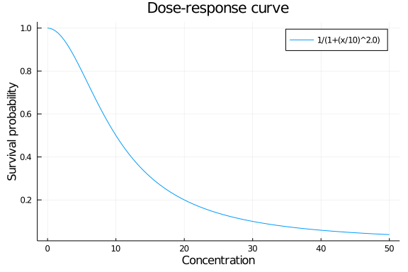

```julia
julia> doseResponse(Cexp,LC50,slope) = 1 ./(1 .+ (Cexp./LC50).^slope)
doseResponse (generic function with 1 method)

julia> Cexp = 0:0.5:50;

julia> LC50=10 ; slope = 2.0;

julia> plot(Cexp, doseResponse(Cexp, LC50,slope), title = "Dose-response curve", label="1/(1+(x/$LC50)^$slope)");

julia> xlabel!("Concentration") ; ylabel!("Survival probability")
```

It’s corresponding selection gradient curve is provided by:

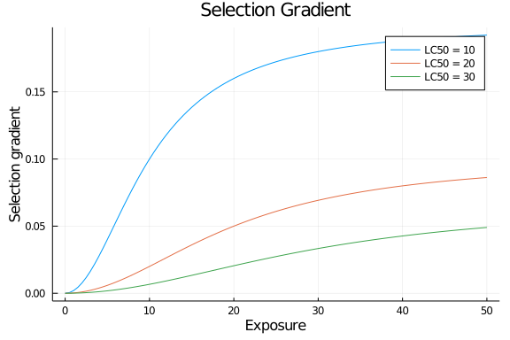

```julia
julia> selectiongradient(Cexp,LC50,slope) = (slope.*(Cexp./LC50).^slope) ./ (LC50 .* ((Cexp ./ LC50).^slope .+ 1))
selectiongradient (generic function with 1 method)

julia> LC50=[10 20 30]
1×3 Array{Int64,2}:
 10  20  30

julia> plot(Cexp, selectiongradient(Cexp, 10,slope),title = "Selection Gradient", label = "LC50 = 10");

julia> xlabel!("Exposure") ; ylabel!("Selection gradient");

julia> plot!(Cexp, selectiongradient(Cexp, 20,slope),label = "LC50 = 20");

julia> plot!(Cexp, selectiongradient(Cexp, 30,slope),label = "LC50 = 30")
```

At a specific exposure concentration, The LC50 must shift to reach the maximal selection gradient:

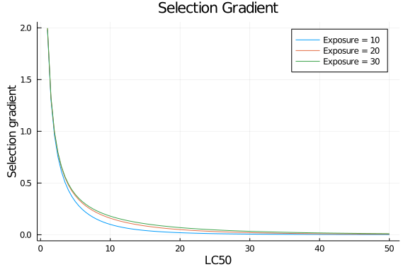

```julia
julia> LC50 = 1:0.5:50
1.0:0.5:50.0

julia> plot(LC50, selectiongradient(10, LC50,slope),title = "Selection Gradient", label = "Exposure = 10");

julia> xlabel!("LC50") ; ylabel!("Selection gradient");

julia> plot!(LC50, selectiongradient(20, LC50,slope),label = "Exposure = 20");

julia> plot!(LC50, selectiongradient(30, LC50,slope),label = "Exposure = 30")
```

## 2.5 Response to selection

We compute in this part the evolution fo the LC50, the trait of selection over a landscape:

$$R_t = V_A β$$

For simplification, we assume that $V_A$ is constant. Since $V_A = h^2 V_P$, a constant $V_A$ means a compensation between $V_P$ and $h^2$.

$$LC_{50}(t+1) = LC_{50}(t) + R_t = LC_{50}(t) + \frac{H(C_{ext}/LC_{50})^H }{((C_{ext}/LC_{50})^H +1 ) LC_{50}}$$

```julia
julia> gridSize = 100
100

julia> LC50init = convert(Array{Float64,2},[i for i in 1:gridSize] * fill(1,gridSize)');

julia> exposure = convert(Array{Float64,2},fill(1,gridSize) * [i for i in 1:gridSize]');

julia> LC50grids = ArrayOutput(LC50init; tspan=1:50, aux=(exposure=exposure,));

julia> rule = Ruleset(SelectionGradientSurvMap(layerkey=Val(:exposure), hillcoefficient=2.0, additiveGeneticVariance = 80.0));

julia> sim!(LC50grids, rule);
```

The LC50 distribution in individuals is as follow:

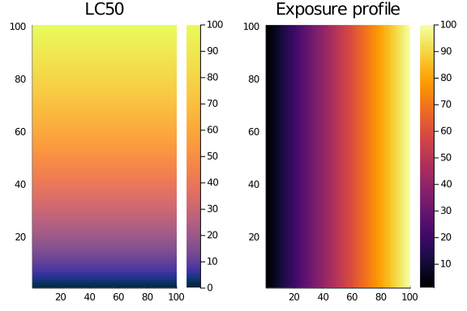

```julia
julia> plot(
           heatmap(LC50init,
                   title = "LC50",
                   c = cgrad(:thermal, scale = :exp),
                   clims=(0.0, 100.0)),
           heatmap(exposure, title = "Exposure profile"),
           layout = (1,2)
           )
```

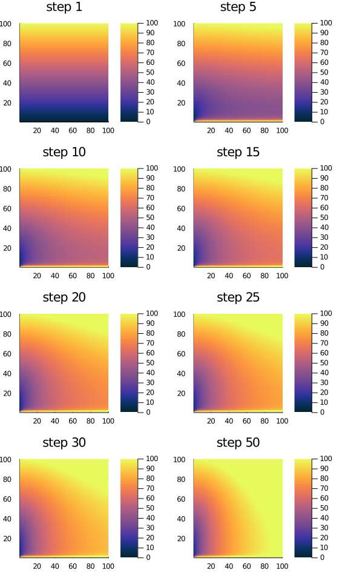

```julia
julia> plt = [ heatmap(
                   LC50grids[i],
                   title = "step $i",
                   c = cgrad(:thermal),
                   clims=(0.0, 100.0)) for i in 1:length(LC50grids)];

julia> plot(plt[1],plt[5],plt[10],plt[15],plt[20],plt[25],plt[30],plt[50], layout = (4,2))
```

# 3 Allele Frequency model

Let say we have a single locus with two allele *R* and *S*, with respective frequency $p$ and $q = 1-p$.

| Genotype | RR | RS | SS |
| --- | --- | --- | --- |
| Frequency in newborns | $p^2$ | $2pq$ | $q^2$ |
| Viability | $w_{RR}$ | $w_{RS}$ | $w_{SS}$ |
| Frequency after selection | $p^2w_{RR}/\bar{w}$ | $2pqw_{RS}/\bar{w}$ | $q^2w_{SS}/\bar{w}$ |
| Relative viability | $1$ | $w_{RS}/w_{RR}$ | $w_{RS}/w_{RR}$ |
| Relative fitness | $1$ | $1-hs$ | $1-s$ |
| Average phenotype | $\mu + \alpha$ | $\mu + d$ | $\mu - \alpha$ |

In the previous table we have

1. the selection coefficient, $s$: measure fitness of SS relative to RR. (1) $s>0$ RR is more fit, (2) $s<0$ SS is more fit
2. the heterozygous effect, $h$: measure of fitness of heterozygous vs homozygous: (1) $h=0$ R dominant, S recessive, (2) $h=1$ S dominant, R recessive, (3) $h<0$ overdominance, (4) $h1$ underdominance, (5) $0 < h < 1$ incomplete dominance.
3. the phenotype response, with $\mu$ a positive constant, (1) $2 \alpha$ is the average phenotypic difference between the two homozygous, (2) $d$ is the degree of dominance between the two alleles ($d=0$ for codominance, $d=1$ when R is dominant, $d=-1$ when R is recessive).

We have the following rules:

- frequency after selection $∝$ newborn-frequency $\times$ viability
- phenotype: $z = \mu + \alpha x_{RR} + d x_{RS} - \alpha x_{SS}$
- mean phenotype: $\bar{z} = \mu + \alpha p^2 + d 2pq - \alpha q^2$

## 3.1 Single-generation change in the frequency of R

The single-generation change in the frequency of R is given by:

$$\Delta p = \frac{pqs (ph +q(1-h)}{\bar{w}}$$

with $\bar{w} = 1-2pqhs-q^2s$

The Wright’s equation give the following result:

$$\Delta p = \frac{pq}{2\bar{w}} \times \frac{\partial \bar{w}}{\partial p} =
\frac{pq}{2\bar{w}} \times \frac{\partial \bar{w}}{\partial \bar{z}} \times \frac{\partial \bar{z}}{\partial p}$$

We wrote previously that:

$$\bar{z} = \mu + \alpha p^2 + d 2pq - \alpha q^2 = \mu + \alpha p^2 + d 2p(1-p) - \alpha (1-p)^2$$

So then:

$$\frac{\partial \bar{z}}{\partial p} = 2 \alpha p + 2 d(1-2p) + 2 \alpha(1-p) = 2(\alpha -2dp+d) = 2(\alpha + d(1-2p)) = 2(\alpha + d(q-p))$$

$$\Delta p = \frac{pq}{2\bar{w}} \times 2(\alpha + d(q-p)) \times \frac{\partial \bar{w}}{\partial \bar{z}} =
2(\alpha -2dp+d) \times \frac{pq}{2} \times \beta = pq(\alpha + d(q-p)) \times \beta$$

Note also the following equality:
$$\Delta p = p_{t+1} - p_t = (1-q_{t+1}) - (1-q_t) = q_t - q_{t+1} = - \Delta q$$

$$\Delta q = - pq( \alpha + d(q-p)) \times \beta$$

And therefore, using the survival log-logistic model:

$$\Delta p = pq(\alpha + d(q-p)) \times \beta = pq(\alpha + d(q-p)) \frac{H(C_{ext}/LC_{50})^H }{((C_{ext}/LC_{50})^H +1 ) LC_{50}}$$

$$p(t+1) = p(t) + \Delta p(t) = p(t) + p(t)(1-p(t))(\alpha + d(1-2p(t))) \frac{H(C_{ext}/LC_{50}(t))^H }{((C_{ext}/LC_{50}(t))^H +1 ) LC_{50}(t)}$$

The frequency of the resistant allele, p(t), is supposed to change the $LC_{50}$. Here we assume a constant $LC_{50}$ for simulation

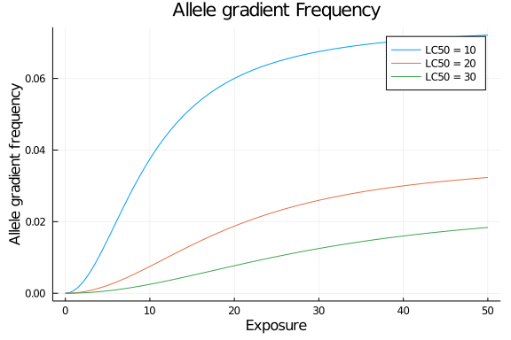

```julia
julia> alleleGradFreqDelta(Cexp,LC50,slope, alpha,d,p) = p.*(1 .-p).*(alpha .+ d.*((1 .-p) .-p)).*(slope.*(Cexp./LC50).^slope) ./ (LC50 .* ((Cexp ./ LC50).^slope .+ 1))
alleleGradFreqDelta (generic function with 1 method)

julia> LC50=[10 20 30]
1×3 Array{Int64,2}:
 10  20  30

julia> alpha = 1.5
1.5

julia> d = 0.9
0.9

julia> p = 0.5
0.5

julia> plot(Cexp, alleleGradFreqDelta(Cexp,LC50[1],slope, alpha,d,p),title = "Allele gradient Frequency", label = "LC50 = 10");

julia> xlabel!("Exposure") ; ylabel!("Allele gradient frequency");

julia> plot!(Cexp, alleleGradFreqDelta(Cexp, LC50[2],slope, alpha,d,p),label = "LC50 = 20");

julia> plot!(Cexp, alleleGradFreqDelta(Cexp, LC50[3],slope, alpha,d,p),label = "LC50 = 30")
```

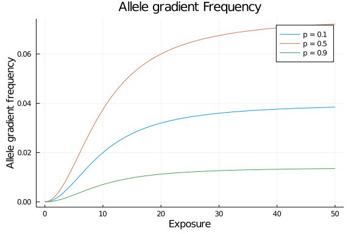

```julia
julia> LC50=10
10

julia> alpha = 1.5
1.5

julia> d = 0.9
0.9

julia> p = [0.1 0.5 0.9]
1×3 Array{Float64,2}:
 0.1  0.5  0.9

julia> plot(Cexp, alleleGradFreqDelta(Cexp,LC50,slope, alpha,d,p[1]),title = "Allele gradient Frequency", label = "p = 0.1");

julia> xlabel!("Exposure") ; ylabel!("Allele gradient frequency");

julia> plot!(Cexp, alleleGradFreqDelta(Cexp, LC50,slope, alpha,d,p[2]),label = "p = 0.5");

julia> plot!(Cexp, alleleGradFreqDelta(Cexp, LC50,slope, alpha,d,p[3]),label = "p = 0.9")
```

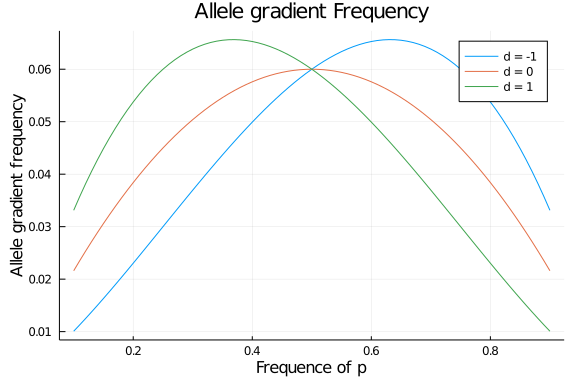

```julia
julia> LC50 = 10
10

julia> Cexp = 20
20

julia> alpha = 1.5
1.5

julia> d = [-1,0,1]
3-element Array{Int64,1}:
 -1
  0
  1

julia> p = 0.1:0.01:0.9
0.1:0.01:0.9

julia> plot(p, alleleGradFreqDelta(Cexp,LC50,slope, alpha,d[1],p),title = "Allele gradient Frequency", label = "d = -1");

julia> xlabel!("Frequence of p") ; ylabel!("Allele gradient frequency");

julia> plot!(p, alleleGradFreqDelta(Cexp, LC50,slope, alpha,d[2],p),label = "d = 0");

julia> plot!(p, alleleGradFreqDelta(Cexp, LC50,slope, alpha,d[3],p),label = "d = 1")
```

How the strength of environmental exposure tends to promote the selection:

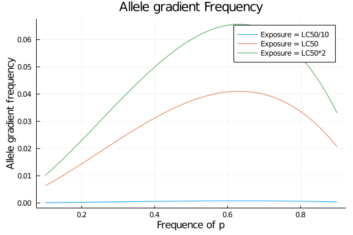

```julia
julia> LC50 = 10
10

julia> Cexp = [LC50/10, LC50, LC50*2]
3-element Array{Float64,1}:
  1.0
 10.0
 20.0

julia> alpha = 1.5
1.5

julia> d = -1
-1

julia> p = 0.1:0.01:0.9
0.1:0.01:0.9

julia> plot(p, alleleGradFreqDelta(Cexp[1],LC50,slope, alpha,d,p),title = "Allele gradient Frequency", label = "Exposure = LC50/10");

julia> xlabel!("Frequence of p") ; ylabel!("Allele gradient frequency");

julia> plot!(p, alleleGradFreqDelta(Cexp[2], LC50,slope, alpha,d,p),label = "Exposure = LC50");

julia> plot!(p, alleleGradFreqDelta(Cexp[3], LC50,slope, alpha,d,p),label = "Exposure = LC50*2")
```

To compared with the dose response curve:

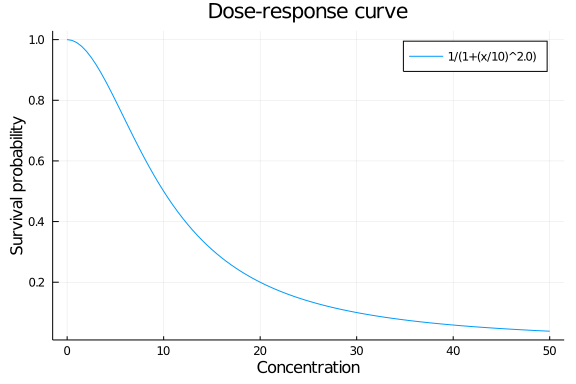

```julia
julia> doseResponse(Cexp,LC50,slope) = 1 ./(1 .+ (Cexp./LC50).^slope)
doseResponse (generic function with 1 method)

julia> Cexp = 0:0.5:50;

julia> plot(Cexp, doseResponse(Cexp, LC50,slope), title = "Dose-response curve", label="1/(1+(x/$LC50)^$slope)");

julia> xlabel!("Concentration") ; ylabel!("Survival probability")
```

```julia
julia> gridSize = 100;

julia> pFreqinit = convert(Array{Float64,2},[i/100 for i in 1:gridSize] * fill(1,gridSize)');

julia> exposure = convert(Array{Float64,2},fill(1,gridSize) * [i for i in 1:gridSize]');

julia> pFreqGrids = ArrayOutput(pFreqinit; tspan=1:50, aux=(exposure=exposure,));

julia> rule = Ruleset(DeltaAlleleFrequencySurvMap(layerkey=Val(:exposure),
                           LC50=50, hillcoefficient=2.0, deviationPhenotype = 2.0, dominanceDegree = -0.8));

julia> sim!(pFreqGrids, rule);
```

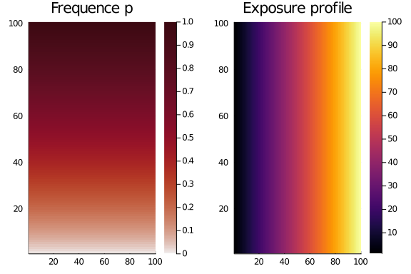

```julia
julia> plot(
           heatmap(pFreqinit,
                   title = "Frequence p",
                   c = cgrad(:amp, scale = :exp),
                   clims=(0.0, 1.0)),
           heatmap(exposure, title = "Exposure profile"),
           layout = (1,2)
           )
```

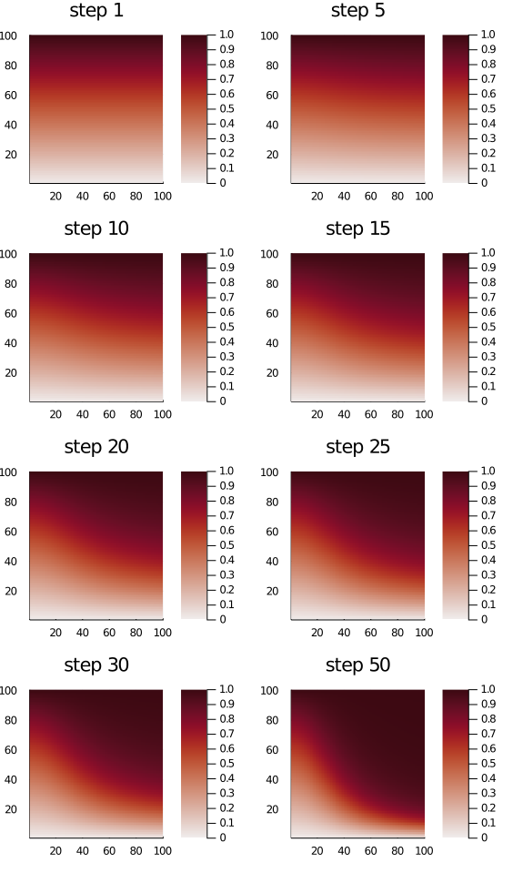

```julia
julia> plt = [ heatmap(
                   pFreqGrids[i],
                   title = "step $i",
                   c = cgrad(:amp),
                   clims=(0.0, 1.0)) for i in 1:length(pFreqGrids)];

julia> plot(plt[1],plt[5],plt[10],plt[15],plt[20],plt[25],plt[30],plt[50], layout = (4,2))
```

# 4 Link between Allele Frequency and Phenotype

We have the mean phenotype given by:

$$\bar{z}_t = \mu + \alpha p^2 + 2 p q d - \alpha q^2$$

So at the next generation, the mean phenotype is given by:

$$\bar{z}_{t+1} = \mu + \alpha (p+\Delta p)^2 + 2 (p+\Delta p) (1-p-\Delta p) d - \alpha (1-p-\Delta p)^2$$

$$\begin{eqnarray}
\Delta \bar{z} &=& \bar{z}_{t+1} - \bar{z}_t \\
&=& \mu + \alpha (p+\Delta p)^2 + 2 (p+\Delta p) (1-p-\Delta p) d - \alpha (1-p-\Delta p)^2 - \mu - \alpha p^2 - 2 p(1-p) d + \alpha (1-p)^2 \\
&=& 2 \Delta p (\alpha + d(1-\Delta p - 2p )) \\
&=& 2 \Delta p (\alpha + d(q - p - \Delta p)) \\
&=& 2 \Delta p (\alpha + d(q - p )) - 2 d(\Delta p)^2
\end{eqnarray}$$

Since we have $\Delta p = pq(\alpha + d(q-p)) \beta$, then:

$$\begin{eqnarray}
\Delta \bar{z} &=& 2 pq (\alpha + d(q - p ))^2 \beta - 2 d (pq(\alpha + d(q-p)) \beta)^2 \\
&=& 2 pq (\alpha + d(q - p ))^2 \beta (1-d \beta)
\end{eqnarray}$$

## 4.1 Selection gradient with frequencies

So using allele frequency, we can have the phenotype using the LC50 model $R_t = \Delta \bar{z}$ :

$$R_t = 2 pq (\alpha + d(q - p ))^2 \beta (1-d \beta)$$

which is

$$R_t = 2 pq (\alpha + d(q - p ))^2 \frac{H(C_{ext}/LC_{50})^H }{((C_{ext}/LC_{50})^H +1 ) LC_{50}} (1-d \frac{H(C_{ext}/LC_{50})^H }{((C_{ext}/LC_{50})^H +1 ) LC_{50}})$$

So at each step, we have to update 2 variables, the frequency of allele $p$ and the phenotype $LC_{50}$.

$$\begin{equation}
\begin{cases}
LC_{50}(t+1) =& LC_{50}(t) + 2 p(t)(1-p(t)) (\alpha + d(1- 2p(t) ))^2 \frac{H(C_{ext}/LC_{50}(t))^H }{((C_{ext}/LC_{50}(t))^H +1 ) LC_{50}(t)}
(1-d \frac{H(C_{ext}/LC_{50}(t))^H }{((C_{ext}/LC_{50}(t))^H +1 ) LC_{50}(t)}) \\
p(t+1) & p(t) + p(t)(1-p(t))(\alpha + d(1-2p(t))) \frac{H(C_{ext}/LC_{50}(t))^H }{((C_{ext}/LC_{50}(t))^H +1 ) LC_{50}(t)}
\end{cases}
\end{equation}$$

**Important**

$$\begin{eqnarray}
z_{RR} = \mu + \alpha + \varepsilon_{RR}
z_{RS} = \mu + d + \varepsilon_{RS}
z_{SS} = \mu - \alpha + \varepsilon_{SS}
\end{eqnarray}$$

We may resonably assume that $\varepsilon_{RR}=\varepsilon_{RS}=\varepsilon_{SS}$.

Giving:
$$\bar{z} = \mu + p^2 \alpha + 2 p q d - q^2\alpha$$

```julia
julia> gridSize = 100;

julia> pFreqinit = convert(Array{Float64,2},[i/100 for i in 1:gridSize] * fill(1,gridSize)');

julia> meanPhenotype = 50.0 # mu
50.0

julia> deviationPhenotype = 30.0 # \alpha
30.0

julia> dominanceDegree = -0.5 # d
-0.5

julia> LC50init = meanPhenotype .+ pFreqinit.^2 .* deviationPhenotype + 2 .* pFreqinit .*(1 .-pFreqinit) - (1 .-pFreqinit).^2 .* deviationPhenotype
100×100 Array{Float64,2}:
 20.6198  20.6198  20.6198  20.6198  …  20.6198  20.6198  20.6198  20.6198
 21.2392  21.2392  21.2392  21.2392     21.2392  21.2392  21.2392  21.2392
 21.8582  21.8582  21.8582  21.8582     21.8582  21.8582  21.8582  21.8582
 22.4768  22.4768  22.4768  22.4768     22.4768  22.4768  22.4768  22.4768
 23.095   23.095   23.095   23.095      23.095   23.095   23.095   23.095
 23.7128  23.7128  23.7128  23.7128  …  23.7128  23.7128  23.7128  23.7128
 24.3302  24.3302  24.3302  24.3302     24.3302  24.3302  24.3302  24.3302
 24.9472  24.9472  24.9472  24.9472     24.9472  24.9472  24.9472  24.9472
 25.5638  25.5638  25.5638  25.5638     25.5638  25.5638  25.5638  25.5638
 26.18    26.18    26.18    26.18       26.18    26.18    26.18    26.18
  ⋮                                  ⋱
 75.3472  75.3472  75.3472  75.3472     75.3472  75.3472  75.3472  75.3472
 75.9302  75.9302  75.9302  75.9302     75.9302  75.9302  75.9302  75.9302
 76.5128  76.5128  76.5128  76.5128     76.5128  76.5128  76.5128  76.5128
 77.095   77.095   77.095   77.095      77.095   77.095   77.095   77.095
 77.6768  77.6768  77.6768  77.6768  …  77.6768  77.6768  77.6768  77.6768
 78.2582  78.2582  78.2582  78.2582     78.2582  78.2582  78.2582  78.2582
 78.8392  78.8392  78.8392  78.8392     78.8392  78.8392  78.8392  78.8392
 79.4198  79.4198  79.4198  79.4198     79.4198  79.4198  79.4198  79.4198
 80.0     80.0     80.0     80.0        80.0     80.0     80.0     80.0

julia> # LC50init = convert(Array{Float64,2},[i for i in 1:gridSize] * fill(1,gridSize)');

       LandeInit = [LandeVariable(pFreqinit[i,j], LC50init[i,j]) for i in 1:gridSize, j in 1:gridSize]
100×100 Array{LandeVariable{Float64,Float64},2}:
 LandeVariable{Float64,Float64}(0.01, 20.6198)  …  LandeVariable{Float64,Float64}(0.01, 20.6198)
 LandeVariable{Float64,Float64}(0.02, 21.2392)     LandeVariable{Float64,Float64}(0.02, 21.2392)
 LandeVariable{Float64,Float64}(0.03, 21.8582)     LandeVariable{Float64,Float64}(0.03, 21.8582)
 LandeVariable{Float64,Float64}(0.04, 22.4768)     LandeVariable{Float64,Float64}(0.04, 22.4768)
 LandeVariable{Float64,Float64}(0.05, 23.095)      LandeVariable{Float64,Float64}(0.05, 23.095)
 LandeVariable{Float64,Float64}(0.06, 23.7128)  …  LandeVariable{Float64,Float64}(0.06, 23.7128)
 LandeVariable{Float64,Float64}(0.07, 24.3302)     LandeVariable{Float64,Float64}(0.07, 24.3302)
 LandeVariable{Float64,Float64}(0.08, 24.9472)     LandeVariable{Float64,Float64}(0.08, 24.9472)
 LandeVariable{Float64,Float64}(0.09, 25.5638)     LandeVariable{Float64,Float64}(0.09, 25.5638)
 LandeVariable{Float64,Float64}(0.1, 26.18)        LandeVariable{Float64,Float64}(0.1, 26.18)
 ⋮                                              ⋱
 LandeVariable{Float64,Float64}(0.92, 75.3472)     LandeVariable{Float64,Float64}(0.92, 75.3472)
 LandeVariable{Float64,Float64}(0.93, 75.9302)     LandeVariable{Float64,Float64}(0.93, 75.9302)
 LandeVariable{Float64,Float64}(0.94, 76.5128)     LandeVariable{Float64,Float64}(0.94, 76.5128)
 LandeVariable{Float64,Float64}(0.95, 77.095)      LandeVariable{Float64,Float64}(0.95, 77.095)
 LandeVariable{Float64,Float64}(0.96, 77.6768)  …  LandeVariable{Float64,Float64}(0.96, 77.6768)
 LandeVariable{Float64,Float64}(0.97, 78.2582)     LandeVariable{Float64,Float64}(0.97, 78.2582)
 LandeVariable{Float64,Float64}(0.98, 78.8392)     LandeVariable{Float64,Float64}(0.98, 78.8392)
 LandeVariable{Float64,Float64}(0.99, 79.4198)     LandeVariable{Float64,Float64}(0.99, 79.4198)
 LandeVariable{Float64,Float64}(1.0, 80.0)         LandeVariable{Float64,Float64}(1.0, 80.0)

julia> exposure = convert(Array{Float64,2},fill(1,gridSize) * [i for i in 1:gridSize]');

julia> LandeGrids = ArrayOutput(LandeInit; tspan=1:50, aux=(exposure=exposure,));

julia> rule = Ruleset(SelectionGradient1locusSurvMap(
                   layerkey=Val(:exposure), hillcoefficient=2.0,  deviationPhenotype = deviationPhenotype, dominanceDegree = dominanceDegree)
               );

julia> sim!(LandeGrids, rule);
```

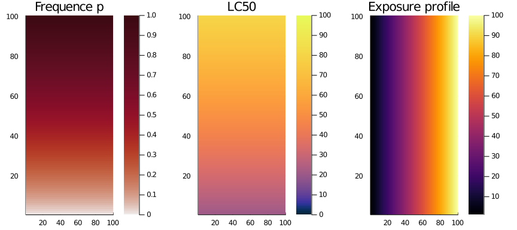

```julia
julia> plot(
           heatmap(pFreqinit,
                   title = "Frequence p",
                   c = cgrad(:amp, scale = :exp),
                   clims=(0.0, 1.0)),
           heatmap(LC50init,
                   title = "LC50",
                   c = cgrad(:thermal, scale = :exp),
                   clims=(0.0, 100.0)),
           heatmap(exposure, title = "Exposure profile"),
           layout = (1,3)
           )
```

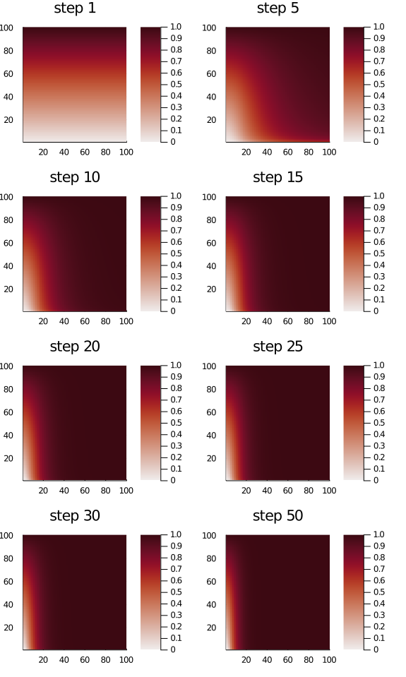

```julia
julia> FreqGrids = [[LandeGrids[k][i,j].alleleFrequency for i in 1:gridSize, j in 1:gridSize] for k in 1:length(LandeGrids)];

julia> plt = [ heatmap(
                   FreqGrids[i],
                   title = "step $i",
                   c = cgrad(:amp),
                   clims=(0.0, 1.0)) for i in 1:length(FreqGrids)];

julia> plot(plt[1],plt[5],plt[10],plt[15],plt[20],plt[25],plt[30],plt[50], layout = (4,2))
```

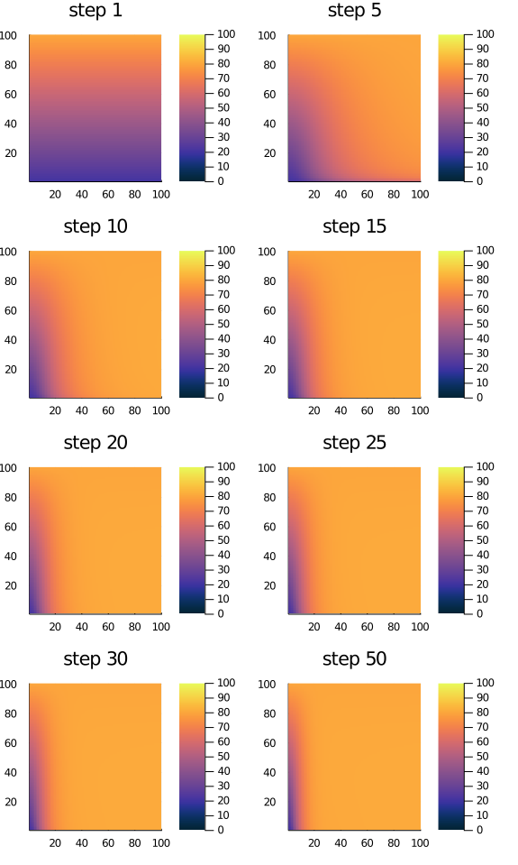

```julia
julia> LC50Grids = [[LandeGrids[k][i,j].phenotype for i in 1:gridSize, j in 1:gridSize] for k in 1:length(LandeGrids)];

julia> plt = [ heatmap(
                   LC50Grids[i],
                   title = "step $i",
                   c = cgrad(:thermal),
                   clims=(0.0, 100.0)) for i in 1:length(LC50Grids)];

julia> plot(plt[1],plt[5],plt[10],plt[15],plt[20],plt[25],plt[30],plt[50], layout = (4,2))
```

Do we obtain the good LC50 grids at step 50?

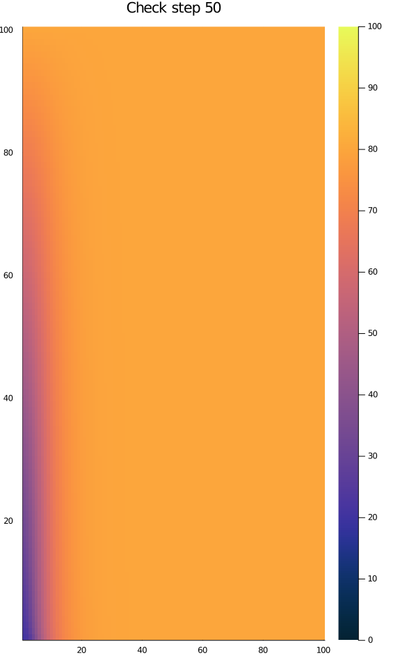

```julia
julia> pFreq_atT50 = FreqGrids[50]
100×100 Array{Float64,2}:
 0.0137628  0.0323867  0.0896378  …  1.0  1.0  1.0  1.0  1.0  1.0  1.0
 0.026623   0.0552209  0.123532      1.0  1.0  1.0  1.0  1.0  1.0  1.0
 0.038817   0.0734666  0.145669      1.0  1.0  1.0  1.0  1.0  1.0  1.0
 0.0505054  0.0890405  0.162651      1.0  1.0  1.0  1.0  1.0  1.0  1.0
 0.061802   0.102886   0.176771      1.0  1.0  1.0  1.0  1.0  1.0  1.0
 0.0727902  0.115536   0.189097   …  1.0  1.0  1.0  1.0  1.0  1.0  1.0
 0.0835324  0.127321   0.20021       1.0  1.0  1.0  1.0  1.0  1.0  1.0
 0.0940767  0.13846    0.21046       1.0  1.0  1.0  1.0  1.0  1.0  1.0
 0.10446    0.149105   0.220077      1.0  1.0  1.0  1.0  1.0  1.0  1.0
 0.114713   0.159365   0.229215      1.0  1.0  1.0  1.0  1.0  1.0  1.0
 ⋮                                ⋱            ⋮
 0.920511   0.922022   0.924469      1.0  1.0  1.0  1.0  1.0  1.0  1.0
 0.930442   0.931749   0.933867      1.0  1.0  1.0  1.0  1.0  1.0  1.0
 0.940374   0.941482   0.943277      1.0  1.0  1.0  1.0  1.0  1.0  1.0
 0.950308   0.951221   0.952701      1.0  1.0  1.0  1.0  1.0  1.0  1.0
 0.960244   0.960965   0.962137   …  1.0  1.0  1.0  1.0  1.0  1.0  1.0
 0.970181   0.970716   0.971585      1.0  1.0  1.0  1.0  1.0  1.0  1.0
 0.980119   0.980472   0.981045      1.0  1.0  1.0  1.0  1.0  1.0  1.0
 0.990059   0.990233   0.990517      1.0  1.0  1.0  1.0  1.0  1.0  1.0
 1.0        1.0        1.0           1.0  1.0  1.0  1.0  1.0  1.0  1.0

julia> LC50_atT50 = meanPhenotype .+ pFreq_atT50.^2 .* deviationPhenotype + 2 .* pFreq_atT50 .*(1 .-pFreq_atT50) - (1 .-pFreq_atT50).^2 .* deviationPhenotype
100×100 Array{Float64,2}:
 20.8529  22.0059  25.5415  31.7083  …  80.0  80.0  80.0  80.0  80.0  80.0
 21.6492  23.4176  27.6285  33.7194     80.0  80.0  80.0  80.0  80.0  80.0
 22.4036  24.5441  28.9891  34.9236     80.0  80.0  80.0  80.0  80.0  80.0
 23.1262  25.5047  30.0314  35.8112     80.0  80.0  80.0  80.0  80.0  80.0
 23.8241  26.3577  30.8973  36.5322     80.0  80.0  80.0  80.0  80.0  80.0
 24.5024  27.1365  31.6525  37.1519  …  80.0  80.0  80.0  80.0  80.0  80.0
 25.1651  27.8615  32.3328  37.7049     80.0  80.0  80.0  80.0  80.0  80.0
 25.8151  28.5462  32.9599  38.2111     80.0  80.0  80.0  80.0  80.0  80.0
 26.4547  29.2     33.5479  38.6836     80.0  80.0  80.0  80.0  80.0  80.0
 27.0859  29.8298  34.1063  39.1311     80.0  80.0  80.0  80.0  80.0  80.0
  ⋮                                  ⋱         ⋮
 75.377   75.4651  75.6078  75.7991     80.0  80.0  80.0  80.0  80.0  80.0
 75.956   76.0321  76.1555  76.3211     80.0  80.0  80.0  80.0  80.0  80.0
 76.5346  76.5991  76.7037  76.8441     80.0  80.0  80.0  80.0  80.0  80.0
 77.1129  77.166   77.2522  77.368      80.0  80.0  80.0  80.0  80.0  80.0
 77.691   77.7329  77.8011  77.8928  …  80.0  80.0  80.0  80.0  80.0  80.0
 78.2687  78.2998  78.3503  78.4184     80.0  80.0  80.0  80.0  80.0  80.0
 78.8461  78.8666  78.8999  78.9448     80.0  80.0  80.0  80.0  80.0  80.0
 79.4232  79.4333  79.4498  79.472      80.0  80.0  80.0  80.0  80.0  80.0
 80.0     80.0     80.0     80.0        80.0  80.0  80.0  80.0  80.0  80.0

julia> heatmap(LC50_atT50,
               title = "Check step 50",
               c = cgrad(:thermal),
               clims=(0.0, 100.0))
```

# 5 Combining population dynamics with evolutionnary dynamics of allele and phenotype

```julia
julia> timeLength = 50
50

julia> # LC50 selection response at landscape level
       gridSize = 100;

julia> LC50init = convert(Array{Float64,2},[i for i in 1:gridSize] * fill(1,gridSize)');

julia> pFreqinit = convert(Array{Float64,2},[i/100 for i in 1:gridSize] * fill(1,gridSize)');

julia> LandeInit = [LandeVariable(pFreqinit[i,j], LC50init[i,j]) for i in 1:gridSize, j in 1:gridSize];

julia> exposure = convert(Array{Float64,2},fill(1,gridSize) * [i for i in 1:gridSize]');

julia> LandeGrids = ArrayOutput(LandeInit; tspan=1:timeLength, aux=(exposure=exposure,));

julia> rule = Ruleset(SelectionGradient1locusSurvMap(
                   layerkey=Val(:exposure), hillcoefficient=2.0,  deviationPhenotype = 2.0, dominanceDegree = -0.8)
               );

julia> sim!(LandeGrids, rule);

julia> # Population response at landscape level
       # 1. get the phenotype LC50 grid:
       LC50Grids = [LandeGrids[k][i,j].phenotype for i in 1:gridSize, j in 1:gridSize, k in 1:length(LandeGrids)];

julia> # 2. build the 2 layers stack:
       exposureGrids = repeat(exposure, inner=(1, 1, lastindex(LC50Grids,3)));

julia> survivalParameter = cat(exposureGrids,LC50Grids; dims = 4);

julia> # 3. build pop size grid
       popSizeInit = convert(Array{Float64,2},[i for i in 1:gridSize] * fill(1,gridSize)');

julia> popSizeGrids = ArrayOutput(popSizeInit; tspan=1:timeLength,aux=(survivalParameter=survivalParameter,));

julia> growthRule = DiscreteGrowth(intrinsicrate=2.2);

julia> survivalRule = SurvLogLogisticMap2(layerkey=:survivalParameter);

julia> ruleset = Ruleset(Chain(growthRule, survivalRule));

julia> sim!(popSizeGrids, ruleset);
```

Initial conditions:

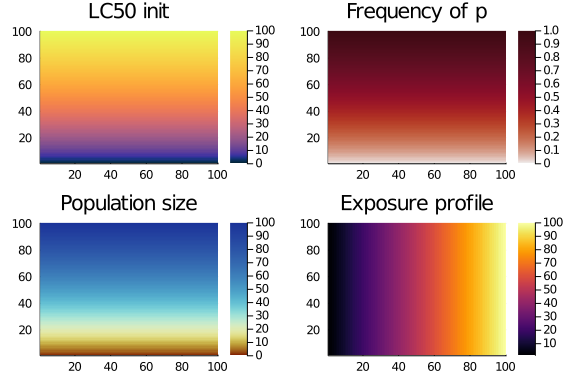

```julia
julia> plot(
           heatmap(LC50init,
                   title = "LC50 init",
                   c = cgrad(:thermal, scale = :exp),
                   clims=(0.0, 100.0)),
           heatmap(pFreqinit,
                   title = "Frequency of p",
                   c = cgrad(:amp, scale = :exp),
                   clims=(0.0, 1.0)),
           heatmap(popSizeInit,
                   title = "Population size",
                   c = cgrad(:roma, scale = :exp),
                   clims=(0.0, 100.0)),
           heatmap(exposure, title = "Exposure profile"),
           layout = (2,2)
           )
```

The resulting populations sequence is given in these graphics:

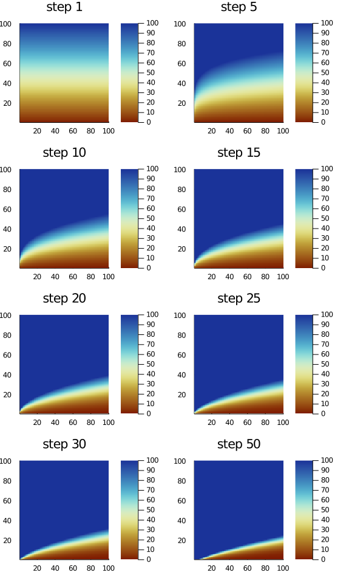

```julia
julia> plt = [ heatmap(
                   popSizeGrids[i],
                   title = "step $i",
                   c = cgrad(:roma),
                   clims=(0.0, 100.0)) for i in 1:length(popSizeGrids)];

julia> plot(plt[1],plt[5],plt[10],plt[15],plt[20],plt[25],plt[30],plt[50], layout = (4,2))
```

The resulting LC50 selection gradient:

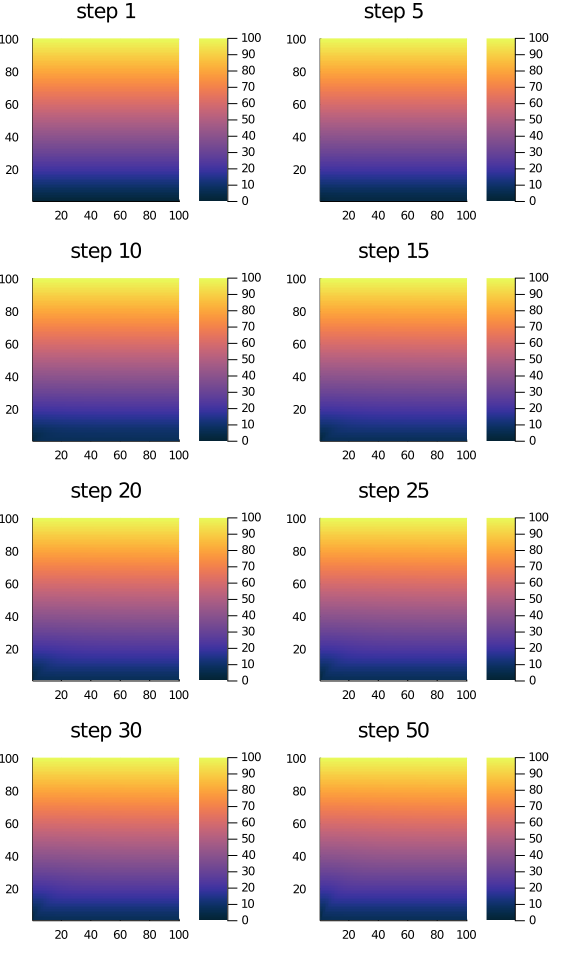

```julia
julia> LC50Grids = [LandeGrids[k][i,j].phenotype for i in 1:gridSize, j in 1:gridSize, k in 1:length(LandeGrids)];

julia> plt = [ heatmap(
                   LC50Grids[:,:,i],
                   title = "step $i",
                   c = cgrad(:thermal),
                   clims=(0.0, 100.0)) for i in 1:lastindex(LC50Grids,3)];

julia> plot(plt[1],plt[5],plt[10],plt[15],plt[20],plt[25],plt[30],plt[50], layout = (4,2))
```

The resulting frequency of the p allele:

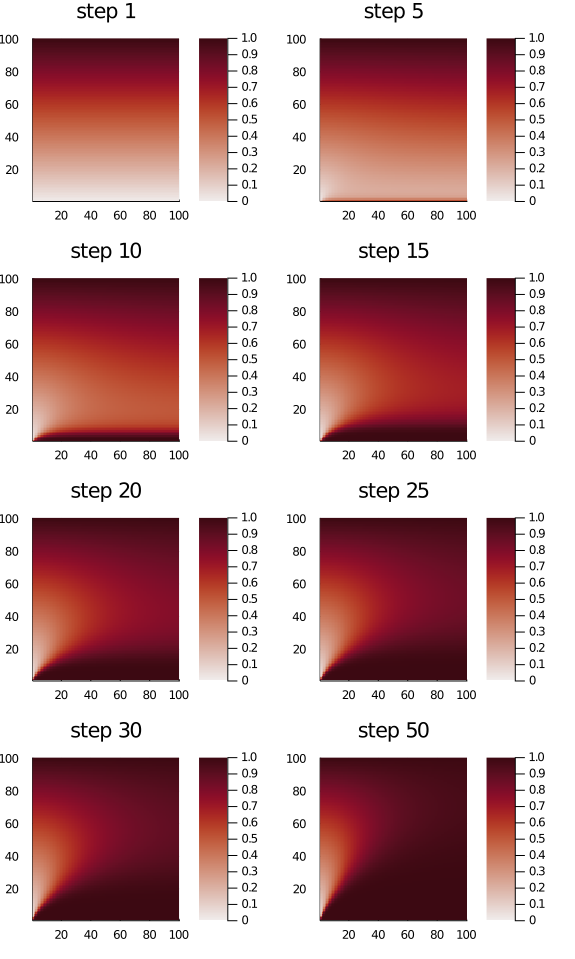

```julia
julia> pFreqGrids = [LandeGrids[k][i,j].alleleFrequency for i in 1:gridSize, j in 1:gridSize, k in 1:length(LandeGrids)];

julia> plt = [ heatmap(
                   pFreqGrids[:,:,i],
                   title = "step $i",
                   c = cgrad(:amp),
                   clims=(0.0, 1.0)) for i in 1:lastindex(pFreqGrids,3)];

julia> plot(plt[1],plt[5],plt[10],plt[15],plt[20],plt[25],plt[30],plt[50], layout = (4,2))
```

```julia
julia> # Population response at landscape level
       # 1. get the phenotype LC50 grid:
       LC50Grids = [LandeGrids[k][i,j].phenotype for i in 1:gridSize, j in 1:gridSize, k in 1:length(LandeGrids)];

julia> # 2. build the 2 layers stack:
       exposureGrids = repeat(exposure, inner=(1, 1, lastindex(LC50Grids,3)));

julia> survivalParameter = cat(exposureGrids,LC50Grids; dims = 4);

julia> # 3. build pop size grid
       popSizeInit = convert(Array{Float64,2},fill(1,gridSize)*[i for i in 1:gridSize]');

julia> popSizeGrids = ArrayOutput(popSizeInit; tspan=1:timeLength,aux=(survivalParameter=survivalParameter,));

julia> growthRule = DiscreteGrowth(intrinsicrate=2.2);

julia> survivalRule = SurvLogLogisticMap2(layerkey=:survivalParameter);

julia> ruleset = Ruleset(Chain(growthRule, survivalRule));

julia> sim!(popSizeGrids, ruleset);
```

The resulting populations sequence is given in these graphics:

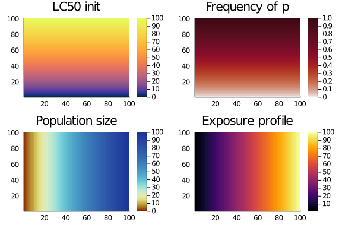

```julia
julia> plot(
           heatmap(LC50init,
                   title = "LC50 init",
                   c = cgrad(:thermal, scale = :exp),
                   clims=(0.0, 100.0)),
           heatmap(pFreqinit,
                   title = "Frequency of p",
                   c = cgrad(:amp, scale = :exp),
                   clims=(0.0, 1.0)),
           heatmap(popSizeInit,
                   title = "Population size",
                   c = cgrad(:roma, scale = :exp),
                   clims=(0.0, 100.0)),
           heatmap(exposure, title = "Exposure profile"),
           layout = (2,2)
           )
```

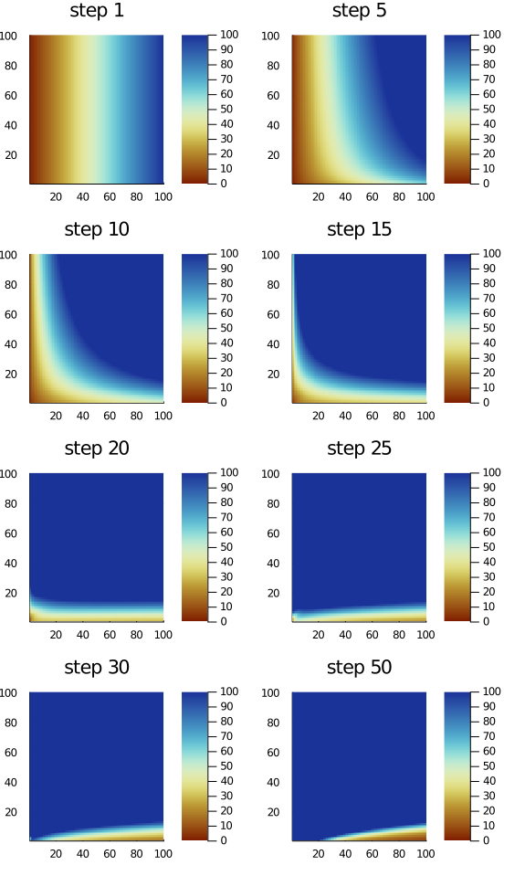

```julia
julia> plt = [ heatmap(
                   popSizeGrids[i],
                   title = "step $i",
                   c = cgrad(:roma),
                   clims=(0.0, 100.0)) for i in 1:length(popSizeGrids)];

julia> plot(plt[1],plt[5],plt[10],plt[15],plt[20],plt[25],plt[30],plt[50], layout = (4,2))
```

# 6 Mating population

## 6.1 Phenotype mating model

Let consider 2 populations with mean phenotype $\bar{z}_1$ for population one, and mean phenotype $\bar{z}_2$ for population two.

Considering population contribute with weight $v_i$ to the mixed generation (i.e. size of the population) **before reproduction**, the model is simply a sum of law (i.e., there convolution). Assuming $z \sim Law(...)$, the additivity of mean and variance of $z$ follow the property of the law.

$$\bar{z}_{mix} = \frac{v_1 \bar{z}_1 + v_2 \bar{z}_2}{v_1 + v_2}$$

Of course, here we just mix both population phenotype the assumption is that we know nothing about underlying genotype.

But it may be that experiment on phenotype allow to provide a continuous scale of “dominance” for mating according to the trait?

Once the population are homogeneously mixed, the previous rule applies.

Let consider a rule that mix 50% of individuals within the cell and 50% of the mean of neighbors (something more detailled could be applied)

```julia
julia> gridSize = 100;

julia> LC50init = convert(Array{Float64,2},[i for i in 1:gridSize] * fill(1,gridSize)');

julia> exposure = convert(Array{Float64,2},fill(1,gridSize) * [i for i in 1:gridSize]');

julia> LC50grids = ArrayOutput(LC50init; tspan=1:50, aux=(exposure=exposure,));

julia> selectionGradientRule = SelectionGradientSurvMap(layerkey=Val(:exposure), hillcoefficient=2.0, additiveGeneticVariance = 80.0);

julia> matingRule = MatingPopulation(Moore(1), 0.5, 0.5);

julia> ruleset = Ruleset(selectionGradientRule,matingRule);

julia> sim!(LC50grids, ruleset);
```

The LC50 and exposure profile is given by:

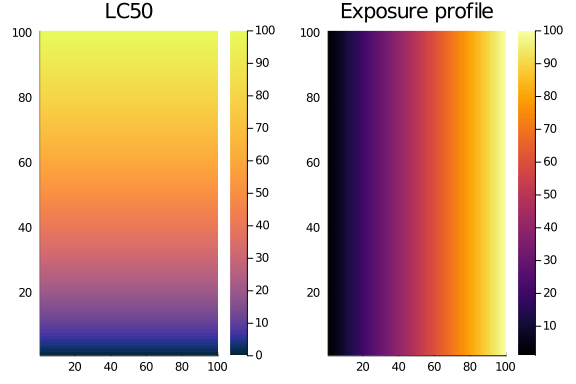

```julia
julia> plot(
           heatmap(LC50init,
                   title = "LC50",
                   c = cgrad(:thermal, scale = :exp),
                   clims=(0.0, 100.0)),
           heatmap(exposure, title = "Exposure profile"),
           layout = (1,2)
           )
```

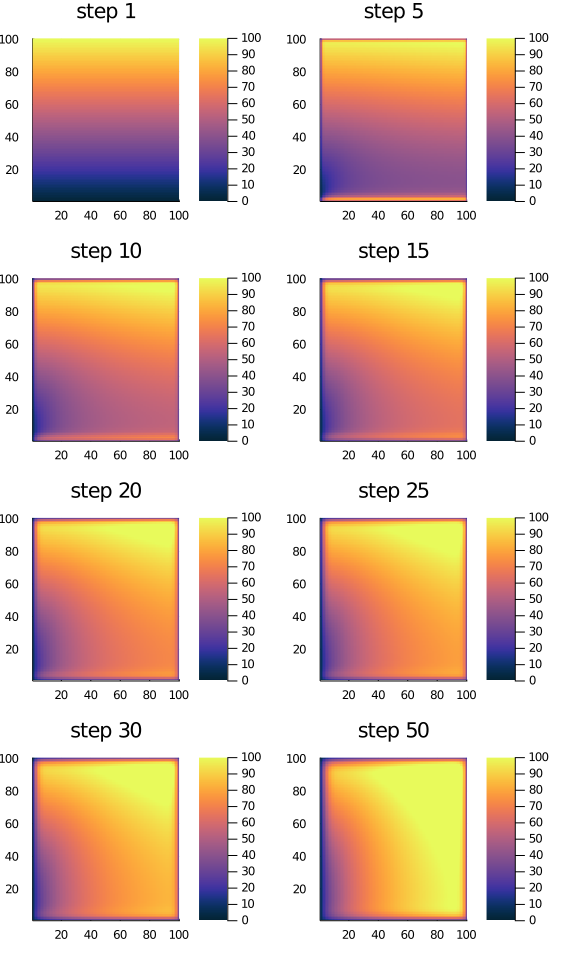

```julia
julia> plt = [ heatmap(
                   LC50grids[i],
                   title = "step $i",
                   c = cgrad(:thermal),
                   clims=(0.0, 100.0)) for i in 1:length(LC50grids)];

julia> plot(plt[1],plt[5],plt[10],plt[15],plt[20],plt[25],plt[30],plt[50], layout = (4,2))
```

## 6.2 Genotype mating model

Let consider 2 populations with genotype:

| Genotype | RR | RS | SS |
| --- | --- | --- | --- |
| Frequency in population 1 | $p_1^2$ | $2p_1q_1$ | $q_1^2$ |
| Frequency in population 2 | $p_2^2$ | $2p_2q_2$ | $q_2^2$ |
| Frequency in mix population | $(v_1p_1^2 + v_2p_2^2)/(v_1+v_2)$ | $(v_12p_1q_1 + v_22p_2q_2)/(v_1+v_2)$ | $(v_1q_1^2+v_2q_2^2)/(v_1+v_2)$ |
| Average phenotype in pop | $\mu + \alpha$ | $\mu + d$ | $\mu - \alpha$ |

$$\frac{v_1p_1^2 + v_2p_2^2 + v_12p_1q_1 + v_22p_2q_2 + v_1q_1^2+v_2q_2^2}{v_1+v_2} = \frac{v_1(p_1^2 +2p_1q_1 + q_1^2) + v_2 (p_2^2 + 2p_2q_2q_2^2)}{v_1+v_2} = 1$$

Then having this new “mixed” population we can run the allele frequency model.

In a cell where the population has $p(t) as the frequency of allele $R$ at time $t$, and we add a new population with $p_2$ frequency, then the frequency of $R$ at time $t+1$ is given by:

$$p(t+1) = \sqrt{\frac{v_1p(t)^2 + v_2p_2^2}{v_1+v_2}}$$

```julia
julia> gridSize = 100;

julia> pFreqinit = convert(Array{Float64,2},[i/100 for i in 1:gridSize] * fill(1,gridSize)');

julia> exposure = convert(Array{Float64,2},fill(1,gridSize) * [i for i in 1:gridSize]');

julia> pFreqGrids = ArrayOutput(pFreqinit; tspan=1:50, aux=(exposure=exposure,));

julia> alleleFrequencyRule = DeltaAlleleFrequencySurvMap(layerkey=Val(:exposure),
                   LC50=50, hillcoefficient=2.0, deviationPhenotype = 2.0, dominanceDegree = -0.8);

julia> matingRule = MatingPopulation(Moore(1), 0.5, 0.5);

julia> ruleset = Ruleset(alleleFrequencyRule,matingRule);

julia> sim!(pFreqGrids, ruleset);
```

The frequency of p when mating with neighbors and exposure profile is given by:

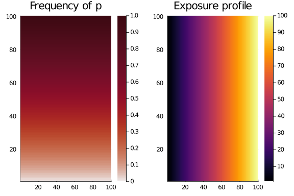

```julia
julia> plot(
           heatmap(pFreqinit,
                   title = "Frequency of p",
                   c = cgrad(:amp, scale = :exp),
                   clims=(0.0, 1.0)),
           heatmap(exposure, title = "Exposure profile"),
           layout = (1,2)
           )
```

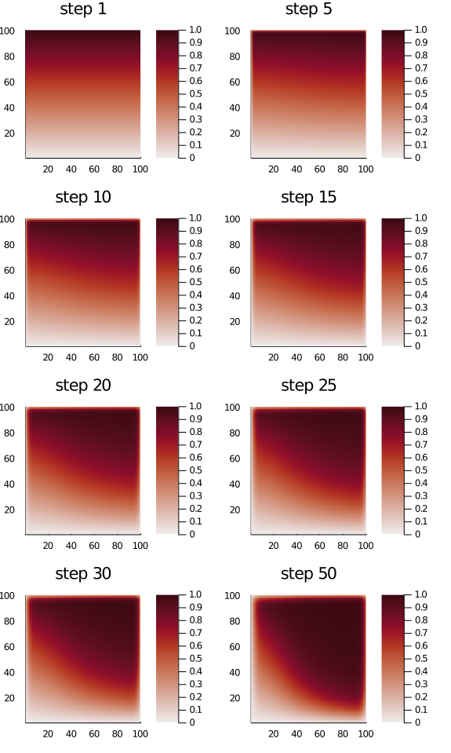

```julia
julia> plt = [ heatmap(
                   pFreqGrids[i],
                   title = "step $i",
                   c = cgrad(:amp),
                   clims=(0.0, 1.0)) for i in 1:length(pFreqGrids)];

julia> plot(plt[1],plt[5],plt[10],plt[15],plt[20],plt[25],plt[30],plt[50], layout = (4,2))
```

# 7 Population Dynamics with Mating and Phenotype/genotype selection under Exposure

## 7.1 Low mating with local population

```julia
julia> # LC50 selection response at landscape level
       gridSize = 100;

julia> LC50init = convert(Array{Float64,2},[i for i in 1:gridSize] * fill(1,gridSize)');

julia> pFreqinit = convert(Array{Float64,2},[i/100 for i in 1:gridSize] * fill(1,gridSize)');

julia> LandeInit = [LandeVariable(pFreqinit[i,j], LC50init[i,j]) for i in 1:gridSize, j in 1:gridSize];

julia> exposure = convert(Array{Float64,2},fill(1,gridSize) * [i for i in 1:gridSize]');

julia> LandeGrids = ArrayOutput(LandeInit; tspan=1:50, aux=(exposure=exposure,));

julia> rule = Ruleset(SelectionGradient1locusSurvMap(
                   layerkey=Val(:exposure), hillcoefficient=2.0,  deviationPhenotype = 2.0, dominanceDegree = -0.8)
               );

julia> sim!(LandeGrids, rule);

julia> # MATING RULES
       # 1. get the phenotype LC50 grid:
       LC50Grids = [LandeGrids[k][i,j].phenotype for i in 1:gridSize, j in 1:gridSize, k in 1:length(LandeGrids)];

julia> matingRule = MatingPopulation(Moore(1), 0.5, 0.5);

julia> ruleset = Ruleset(alleleFrequencyRule,matingRule);

julia> # Population response at landscape level

       # 2. build the 2 layers stack:
       exposureGrids = repeat(exposure, inner=(1, 1, lastindex(LC50Grids,3)));

julia> survivalParameter = cat(exposureGrids,LC50Grids; dims = 4);

julia> # 3. build pop size grid
       popSizeInit = convert(Array{Float64,2},[i for i in 1:gridSize] * fill(1,gridSize)');

julia> popSizeGrids = ArrayOutput(popSizeInit; tspan=1:50,aux=(survivalParameter=survivalParameter,));

julia> growthRule = DiscreteGrowth(intrinsicrate=2.0);

julia> survivalRule = SurvLogLogisticMap2(layerkey=:survivalParameter);

julia> ruleset = Ruleset(Chain(growthRule, survivalRule));

julia> sim!(popSizeGrids, ruleset);
```

Published from using Weave.jl v0.10.6 on 2020-10-29.